# 盈利模式

分析购彩助手数据

特邀导师 - 菜菜

2020-07-26

读取程序包

# 1 数据

## 1.1 样本数据

账号：`zxg00123`，以下是从我们平台购彩助手中的官方数据采集下来的数据，什么彩种都可以分析，就拿个主打**1分快3**为样本。

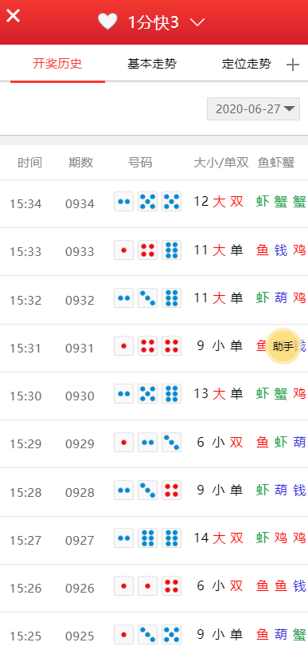

```r
hml <- read.delim(file = '1分快3样本数据2.txt')
hml %<>% unlist %>% as.character

#时间 期数 号码 大小/单双 鱼虾蟹
#12:41 0761 dice1 dice1 dice57 小 单 鱼 鱼 蟹
smp <- c('12:41', '0761', 'dice1 dice1 dice5', '7 小 单', '鱼 鱼 蟹') %>% matrix(nc = 1, byrow = TRUE) %>% t %>% data.frame
nm <- c('时间', '期数', '号码', '大小/单双', '鱼虾蟹')
names(smp) <- nm
smp %<>% tbl_df

smp %>%
  kable(caption = '1分快3样本数据') %>%
  kable_styling(bootstrap_options = c('striped', 'hover', 'condensed', 'responsive'))
```

## 1.2 整理数据

```r
smpp <- hml %>% llply(., function(x) {
    x %>% str_extract_all('([0-9]{2}:[0-9]{2})|([0-9]{1,2}%)|(\\w+)') %>% unlist %>% str_replace_all('2e1d3b04', '') %>% str_replace_all('([0-9]+[a-zA-Z]+)|([a-zA-Z]+)|[0-9]{1,2}%', '') %>% .[nchar(.)>0] %>% t %>% data.frame
}) %>% bind_rows %>% tbl_df
names(smpp) <- c('时间', '期数', '骰子1', '骰子2', '骰子3', '总值', '大小', '单双', '鱼虾蟹1', '鱼虾蟹2', '鱼虾蟹3')

smpp %<>% mutate(
    `时间` = hm(`时间`), `期数` = factor(`期数`),
    `骰子1` = as.numeric(`骰子1`), `骰子2` = as.numeric(`骰子2`),
    `骰子3` = as.numeric(`骰子3`), `总值` = as.numeric(`总值`),
    `大小` = factor(`大小`), `单双` = factor(`单双`),
    `鱼虾蟹1` = factor(`鱼虾蟹1`), `鱼虾蟹2` = factor(`鱼虾蟹2`),
    `鱼虾蟹3` = factor(`鱼虾蟹3`))

smppp <- smpp[c('总值', '大小', '单双')]

smpp %>% datatable(
    caption = "1分快3样本数据",
    escape = FALSE, filter = 'top', rownames = FALSE,
    extensions = list('ColReorder' = NULL, 'RowReorder' = NULL,
                      'Buttons' = NULL, 'Responsive' = NULL),
    options = list(dom = 'BRrltpi', autoWidth = TRUE,  scrollX = TRUE,
                   lengthMenu = list(c(10, 50, 100, -1), c('10', '50', '100', 'All')),
                   ColReorder = TRUE, rowReorder = TRUE,
                   buttons = list('copy', 'print',
                                  list(extend = 'collection',
                                       buttons = c('csv', 'excel', 'pdf'),
                                       text = 'Download'), I('colvis'))))
```

# 2 统计模型

## 2.1 基本分析

```r
smpp[-c(1:2)] %>% llply(table)
```

```r
yy <- suppressMessages(llply(3:18, function(i) {
  dpois(i, smppp$总值) %>% round(2)
}) %>% bind_cols)
names(yy) <- paste0('X', 3:18)
yy <- data.frame(smppp, yy) %>% tbl_df

yy %>%
  kable(caption = '和值概率明细') %>%
  kable_styling(bootstrap_options = c('striped', 'hover', 'condensed', 'responsive')) %>%
  scroll_box(width = '100%', height = '400px')
```

```r
table(smpp$`总值`)
prop.table(table(smpp$`总值`))
barplot(prop.table(table(smpp$`总值`)))
```

```r
table(smpp$`大小`)
prop.table(table(smpp$`大小`))
barplot(prop.table(table(smpp$`大小`)))
```

```r
table(smpp$`单双`)
prop.table(table(smpp$`单双`))
barplot(prop.table(table(smpp$`单双`)))
```

```r
table(smpp$`鱼虾蟹1`)
prop.table(table(smpp$`鱼虾蟹1`))
barplot(prop.table(table(smpp$`鱼虾蟹1`)))
```

```r
table(smpp$`鱼虾蟹2`)
prop.table(table(smpp$`鱼虾蟹2`))
barplot(prop.table(table(smpp$`鱼虾蟹2`)))
```

```r
table(smpp$`鱼虾蟹3`)
prop.table(table(smpp$`鱼虾蟹3`))
barplot(prop.table(table(smpp$`鱼虾蟹3`)))
```